# Large Language Models

*LLMs: Foundations, Generation & Beyond*

Noé Durandard (noe.durandard@psl.eu)

Introduction to NLP — MSc. DH EdC-PSL

November 18, 2025

# …in the real world

## 0.1 Evidences of ChatGPT’s impact

LLMs influence the way we communicate (Yakura et al. 2024; Geng et al. 2024; Anderson, Shah, and Kreminski 2024).

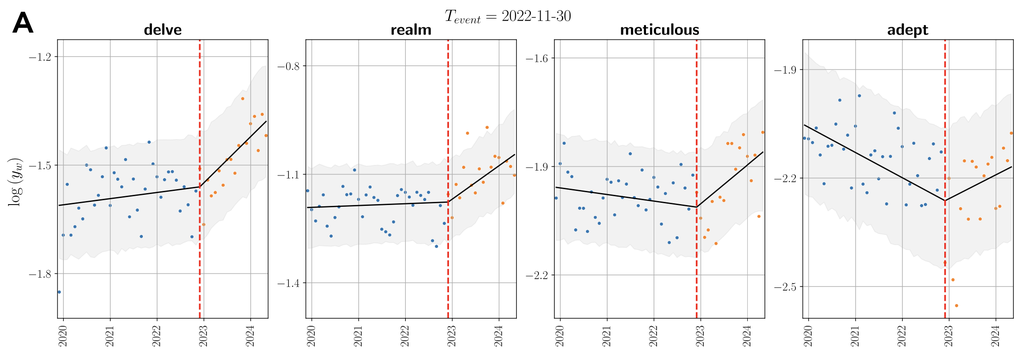

*Prevalence of words associated with ChatGPT. Extracted from (Yakura et al. 2024).*

## 0.2 Influence besides vocabulary

- LLMs **influence** users and participate in **shaping opinion**

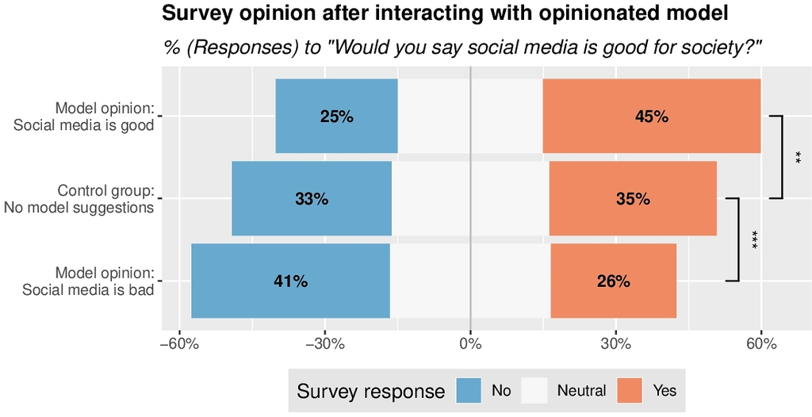

*Participants interacting with a model supportive of social media were more likely to say that social media is good for society in a later survey (and vice versa) — from Jakesch et al. (2023).*

- collective opinion (Li et al. 2023)
- individual opinion (Jakesch et al. 2023; Williams-Ceci et al. 2024)

## 0.3 Propagation of models’ biases

Language is loaded with sociocultural characteristics (Jiang 2000).

$\to$ LLMs biases can have *harmful consequences*, and *spread* in downstream applications:

- lower quality service to minorities and vulnerablue users (Poole-Dayan, Roy, and Kabbara 2024; Cunningham et al. 2024)
- demographic-based recommandations (Salinas et al. 2023)
- mental health issues and cultural values (Hadar-Shoval et al. 2023)
- politically biased text summarization (Yuhan Liu et al. 2024)
- …

# 1 Framing Large Language Models

### 1.0.1 Definition(?)

**Large Language Model - from (Merriam-Webster 2025)**

A language model that utilizes deep [learning] methods on an extremely large data set as a basis for predicting and constructing natural-sounding text.

## 1.1 Large

### 1.1.1 What is a *Large* Language Model?

[figure not shown]

*Extracted from (Thompson 2025).*

### 1.1.2 Scaling Laws & The bitter Lesson

*The bitter Lesson* (Sutton 2019)

> *“general methods that leverage computation are ultimately the most effective, and by a large margin”…*
- **Knowledge** integration helps improve models in the **short term** (rewarding to researchers, but plateaus and can even inhibit further progress)
- **Breakthrough** progress eventually arrives by an opposing approach based on **scaling computation** by *learn* and *search*

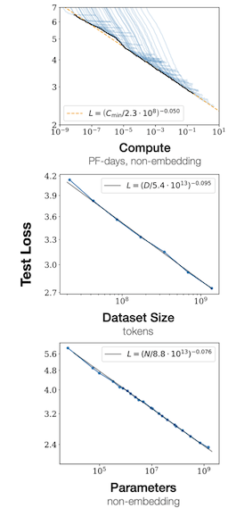

*Language modeling performance improves smoothly as the model size, datasetset size, and amount of compute used for training increase (extracted from (Kaplan et al. 2020)).*

## 1.2 Causal

### 1.2.1 Autoregressive

**Definition**

An autoregressive (AR) model is a representation of a type of stochastic process. It specifies that the output variable (or current state) depends linearly on its own $p$ previous values: $X_{t}=\sum _{i=1}^{p}\varphi _{i}X_{t-i}+\varepsilon _{t}$.

**In NLP**

In NLP, AR models generally refer to *next-token* prediction models, and the linear assumption can be disregarded.

→ $n$-grams $\in$ LLMs ??

### 1.2.2 Decoder-only

- **Only a decoder stack** (no encoder)
- **Causal / masked self-attention**
  - Each token can only attend to *previous* tokens
- Naturally suited for **generation**
  - Trained for next token prediction
  - Produce text left-to-right, one token at a time

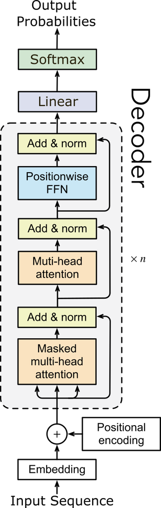

*Transformer Architecture*, based on Vaswani (2017), reworked from (Zhang et al. 2023).

## 1.3 Language Models

### 1.3.1 The Language Modeling Problem (again)

**Language Model**

A Language Model (LM) estimates the probability of pieces of text. Given a sequence of text $w_{1},w_{2},\cdots,w_{S}$, it answers the question:

**What is $P(w_{1},w_{2},\cdots,w_{S})$?**

How to compute $P$?

- Count-based (count): n-gram
- Neural method (learn): Transformer
  - Masked Language Modeling (encoder-only, BERT)
  - Causal Language Modeling (decoder-only, GPT)

$\to$ encode:

- gramaticality
- semantic plausability
- stylistic consistency
- knowledge (?)

# Large (? enough) Autoregressive Causal (→ decoder-only) Language Models

parameters + data

… yes but …

as in

(more or less)

# 2 Training

## 2.1 LLMs training workflow

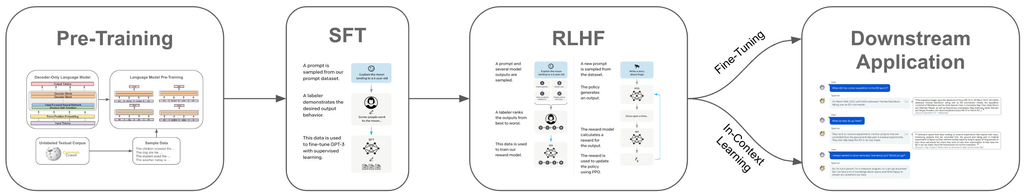

*Overview of LLMs Training Pipeline. Extracted from (Wolfe 2023), based on (Ouyang et al. 2022).*

## 2.2 Pre-training

### 2.2.1 Next token prediction task

$$P(x_{i,t+1} | x_{i,1},\cdots,x_{i,t})$$

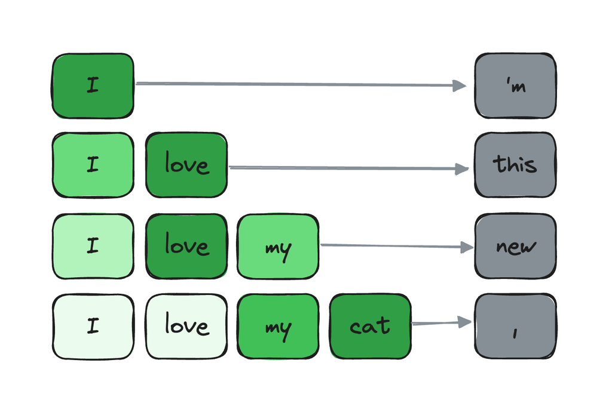

*Example generated with `allenai/OLMo-2-0425-1B` (e.g., training).*

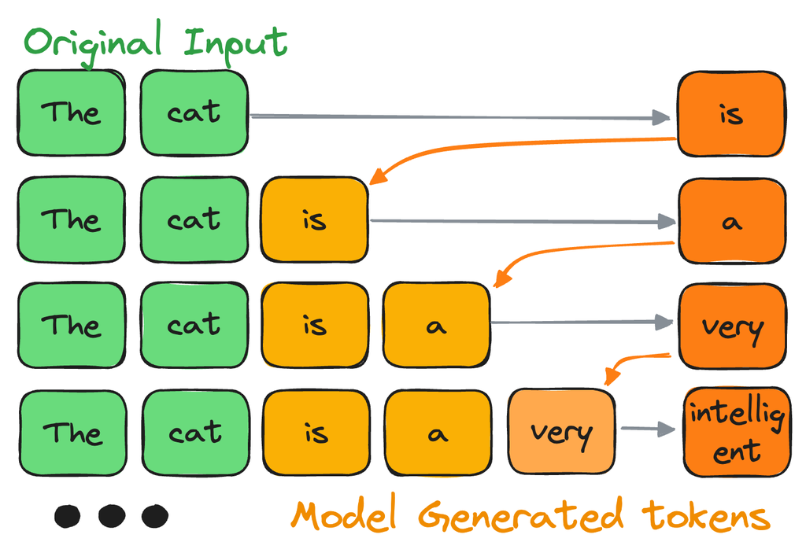

*Example generated with `allenai/OLMo-2-0425-1B` (e.g., generation).*

### 2.2.2 Self-Supervision

**Self-Supervised Learning (Wikipedia 2025)**

Self-supervised learning (SSL) is a paradigm in machine learning where a model is trained on a task using the **data itself** to generate **supervisory signals**, rather than relying on externally-provided labels.

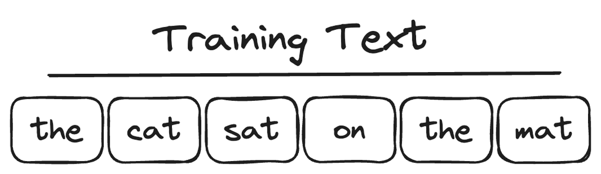

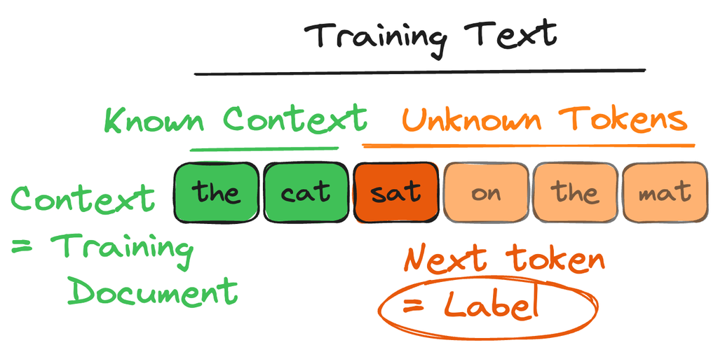

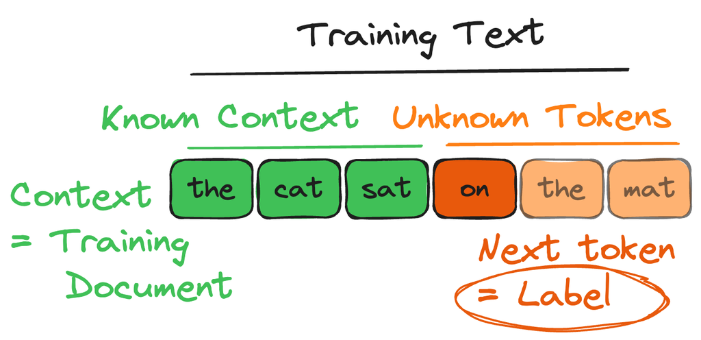

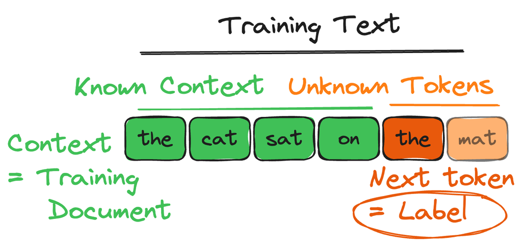

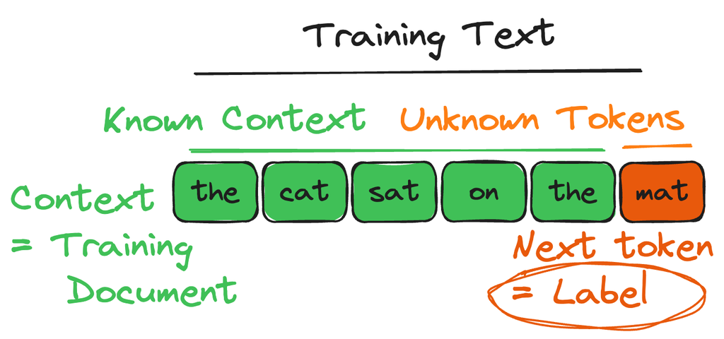

### 2.2.3 Training Objective: Cross-Entropy

$\mathcal{L}[\phi] = - \sum_{i=1}^{I}\sum_{t=1}^{T}\log\left[ P(x_{i,t+1} | x_{i,1},\cdots,x_{i,t},\phi) \right]$

- Penalizes confident wrong predictions heavily
  - Low probability to ‘true’ next token $\Rightarrow$ high loss: $\displaystyle{\lim_{p_i \to 0}}\left(-\log(p_i)\right)=\infty$
- Rewards accurate predictions
  - High probability to ‘true’ next token $\Rightarrow$ low loss: $\displaystyle{\lim_{p_i \to 1}}\left(-\log(p_i)\right)=0$
- Maintains Differentiability
  - smooth mathematical properties allow effective gradient-based optimization

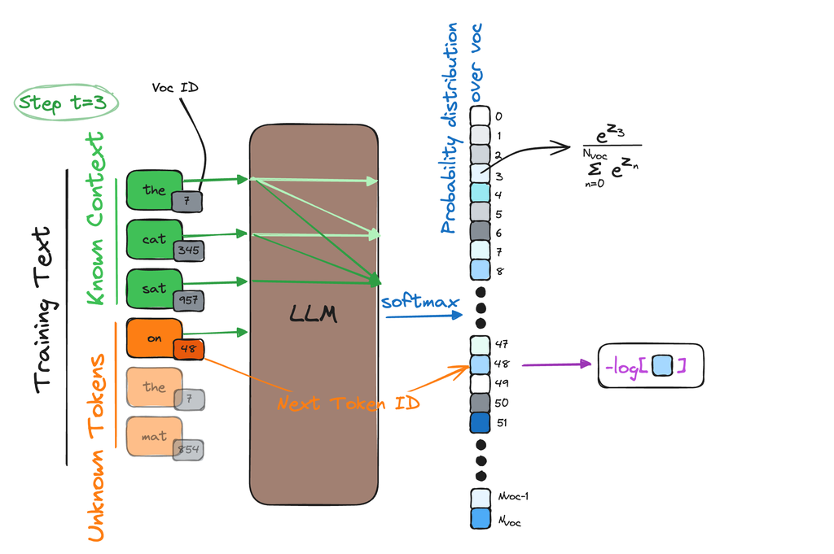

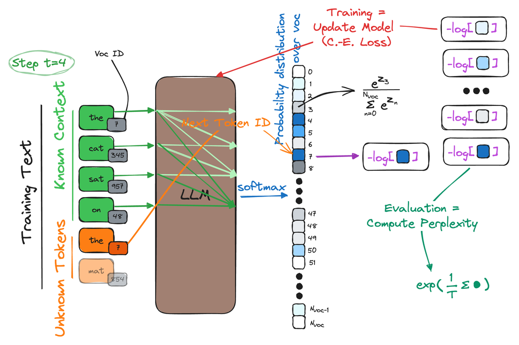

## 2.3 Data

### 2.3.1 Data Sources

**Pre-training** ≈ *learning from the distribution of texts on the internet.*

- Primarily large-scale web crawls
  - Common Crawl, C4, CCNet, Dolma, RefinedWeb, RedPajama
- Curated “high-quality” reference works
  - Wikipedia, books, textbooks, scientific papers
- Code repositories
  - GitHub, StackOverflow

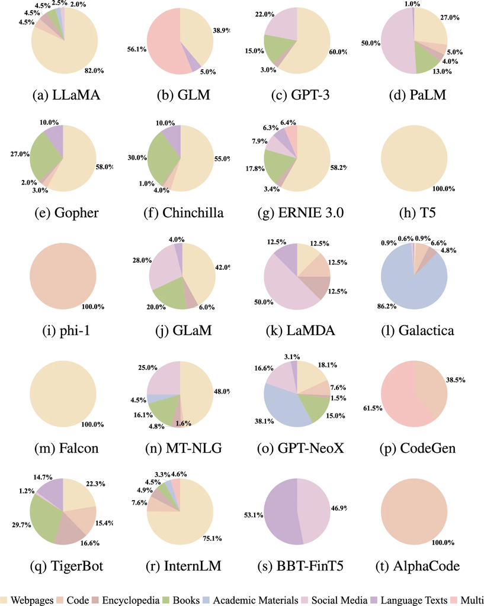

*The distribution of data types in pre-training corpora used by different LLMs. Extracted from Yang Liu et al. (2025).*

### 2.3.2 Data Filtering

Is that so?

```bash
python train_my_llm.py --dataset=extremely_large_dataset
```

Not *that* simple…

[figure not shown]

*Overview of web data processing pipeline for Dolma (Ai2). Extracted from (Soldaini 2023).*

### 2.3.3 *Quality* data?

“Quality” filtering choices…

- Monolingual and high-resource language bias (Wenzek et al. 2019)
- Academic / Formal-style bias (Gururangan et al. 2022)
- Textbook-like datasets (Gunasekar et al. 2023)
- Wikipedia-heavy corpora (Touvron et al. 2023)
- Topic / socio-economic bias (Lucy et al. 2024)

… have consequences!

- Marginalization of low-resource languages, dialects, sociolects
- Overrepresentation of techno-scientific, Western, elite knowledge
- “Highbrow” epistemic bias: formal, rational, encyclopedic styles favored
- Missing registers: oral, vernacular, informal, multilingual mixing, community languages
- Potentially distorted representations of social groups or cultural practices

## 2.4 Post(-pre)-training

### 2.4.1 Supervised (Instruction) Fine-Tuning

**Goal**: Teach model to *follow instructions*.

- Supervised setting
  - instructions & responses
- Uses curated **input → output** examples
  - e.g., “Summarize…”, “Translate…”, “Explain like I’m 5…”

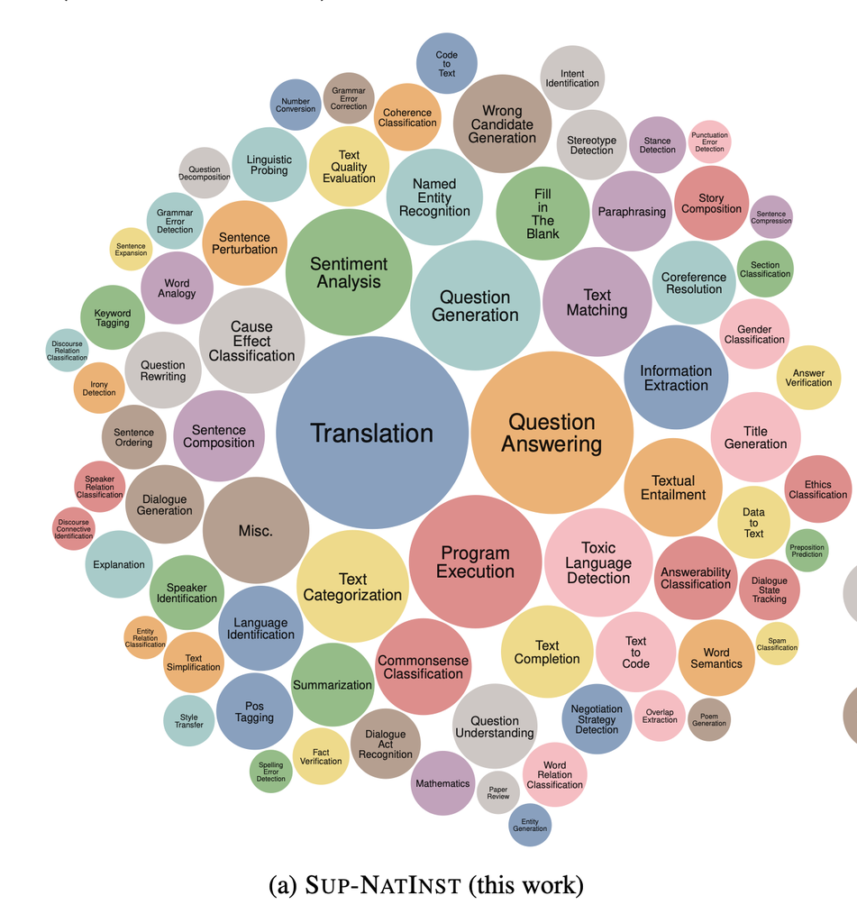

*Task categories present in Super-NaturalInstructions dataset (Wang et al. 2022) (extracted from original article).*

### 2.4.2 RL (from Human Feedback)

**Goal**: Align model with *desired behaviors* (see e.g., (Bai et al. 2022; Ouyang et al. 2022)).

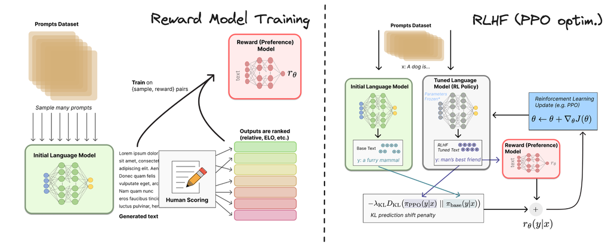

*Extracted from (Lambert et al. 2022).*

# 3 Inference → [Tutorial](https://github.com/d-noe/NLP_DH_PSL_Fall2025/blob/main/code/4_causal/Tutorial_4_LLM_Interaction.ipynb)

### 3.0.1 Use-cases

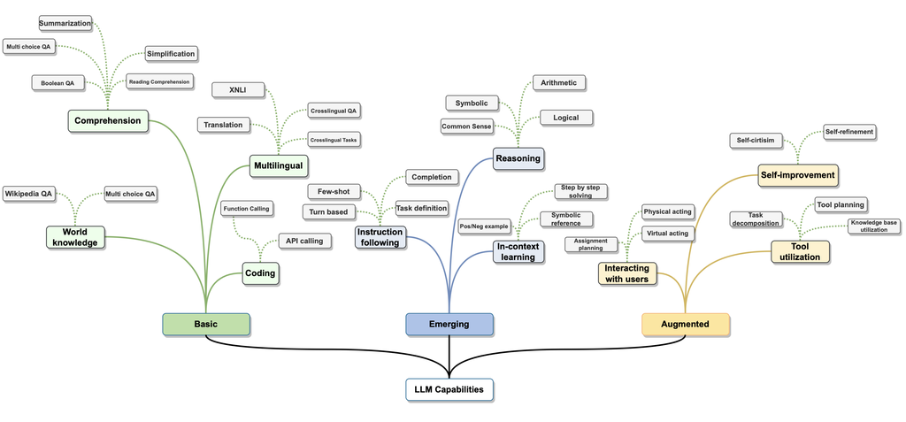

*LLMs Capabilities. Extracted from (Minaee et al. 2025).*

## 3.1 Prompt Strucutre

### 3.1.1 Elements of a Prompt

Natural Language Interaction:

- System prompt
  - set of instructions, guidelines, and contextual information provided to AI models before they engage with user queries.
- User prompt
  - actual message of the user
    - Instruction: definition of the task
    - Examples: provide examples (as in few-shot)
    - Context: provide additional context to address the problem
    - Quesiton: prompt the model to solve the task

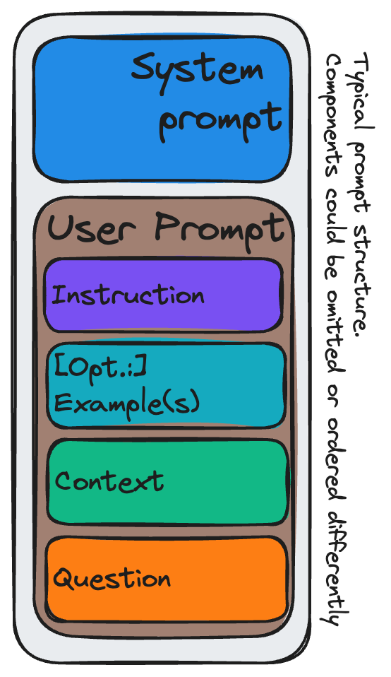

### 3.1.2 Example: Under the Hood

- UI
- Prompt
- Code
- Multi-turn
- Multi-turn code

[figure not shown]

*Screenshot of OLMo playground (https://playground.allenai.org/?model=cs-OLMo-2-1124-7B-Instruct)*

Example for OLMo-2-Instruct:

```
 <|endoftext|><|system|>
 You are a helpful assistant.
 <|user|>
 Who are you?
 <|assistant|>
```

Example for Qwen2.5-Instruct:

```
 <|im_start|>system
 You are a helpful assistant. <|im_end|> <|im_start|>user
 Who are you?  <|im_end|> <|im_start|>assistant
```

Example for Llama-3.1-Instruct:

```
 <|begin_of_text|><|start_header_id|>system<|end_header_id|>

 Cutting Knowledge Date: December 2023 Today Date: 26 Jul 2024

 You are a helpful assistant.<|eot_id|><|start_header_id|>user<|end_header_id|>

 Who are you? <|eot_id|><|start_header_id|>assistant<|end_header_id|>
```

```python
messages = [ # contains chat history as a list of dict where each instance has:
    {
      "role": "system",                          # role (*system*|user|assistant)
      "content": "You are a helpful assistant."  # content of the message
    },
    {
      "role": "user",                            # role (system|*user*|assistant)
      "content": "Who are you?"                  # content of the message
    },
]
inputs = tokenizer.apply_chat_template( # Apply chat template + tokenize
    messages,                             # provide chat history
    add_generation_prompt=True,           # add generation prompt (assistant:...)
    tokenize=True,                        # do tokenize the input
    return_dict=True,
    return_tensors="pt",
).to(model.device)

outputs = model.generate(**inputs, max_new_tokens=40)
print(tokenizer.decode(outputs[0][inputs["input_ids"].shape[-1]:]))
```

OLMo-2-Instruct style:

```
 <|endoftext|><|system|>
 You are a helpful assistant.
 <|user|>
 Who are you?
 <|assistant|>
 I am an AI assistant.
 <|user|>
 What can you do for me?
 <|assistant|>
 I can do all sorts of things.
 <|user|>
 What exactly?
 <|assistant|>
```

```python
messages = [ # contains chat history as a list of dict where each instance has:
    {
      "role": "system",                          # role (*system*|user|assistant)
      "content": "You are a helpful assistant."  # content of the message
    },
    {
      "role": "user",                            # role (system|*user*|assistant)
      "content": "Who are you?"                  # content of the message
    },
    {
      "role": "assistant",                       # role (system|user|*assistant*)
      "content": "I am an AI assistant."         # content of the message
    },
    {
      "role": "user",                            # role (system|*user*|assistant)
      "content": "What can you do for me?"       # content of the message
    },
    {
      "role": "assistant",                       # role (system|user|*assistant*)
      "content": "I can do all sorts of things." # content of the message
    },
    {
      "role": "user",                            # role (system|*user*|assistant)
      "content": "What exactly?"                 # content of the message
    },
    # and so on ...
]
inputs = tokenizer.apply_chat_template( # Apply chat template + tokenize
    messages,                             # provide chat history
    add_generation_prompt=True,           # add generation prompt (assistant:...)
    tokenize=True,                        # do tokenize the input
    return_dict=True,
    return_tensors="pt",
).to(model.device)

outputs = model.generate(**inputs, max_new_tokens=40)
print(tokenizer.decode(outputs[0][inputs["input_ids"].shape[-1]:]))
```

### 3.1.3 Nice visualization [here](https://poloclub.github.io/transformer-explainer/) (Cho et al. 2024):

## 3.2 Sampling

### 3.2.1 Next-token probability distribution

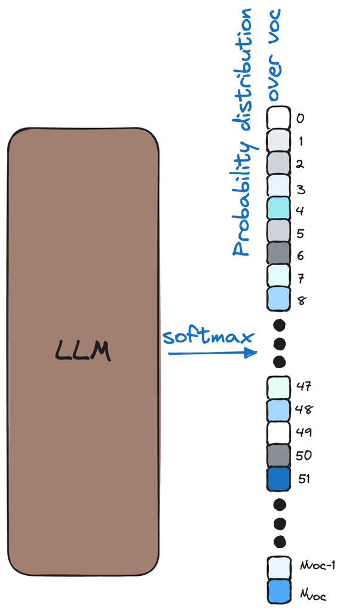

$$P_i=\frac{e^{\frac{z_i}{T}}}{\displaystyle\sum_{j=1}^{N_\mathrm{voc}}e^{\frac{z_j}{T}}}$$

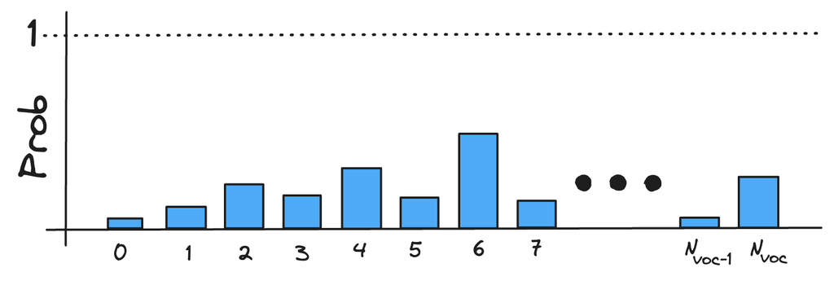

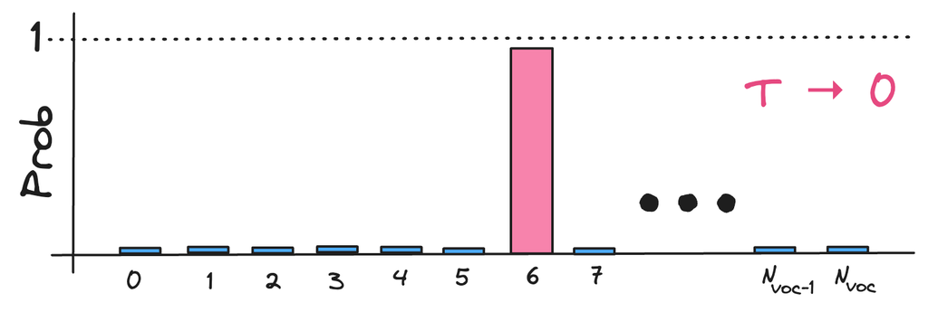

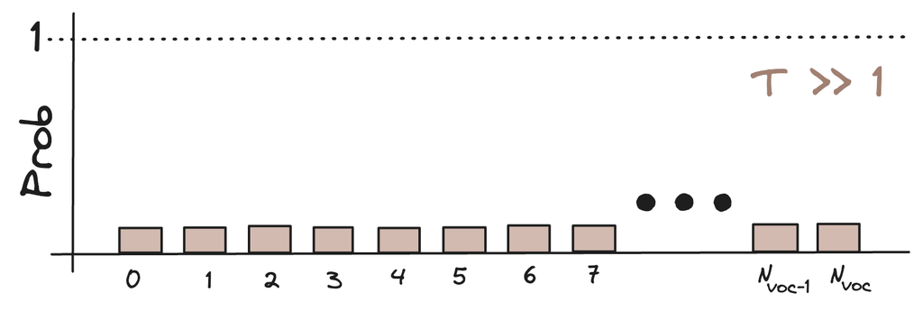

### 3.2.2 Some Other Generation Parameters

- **temperature**
  - Controls *“creativity” vs. determinism*.
    - ↓ low (0–0.7): predictable, focused, factual
    - ↑ high (1.0+): diverse, surprising, risk of incoherence
- **top-k**
  - Keep only the **k most likely** next tokens.
    - small k → conservative, avoids rare tokens
    - large k → more expressive, less stable
- **top-p (nucleus sampling)**
  - Keep the **smallest set** of tokens whose cumulative probability ≥ p.
    - p≈0.0: only most likely token
    - p≈0.9: diverse but meaningful
    - p≈1.0: no filtering
- **length_penalty**
  - Encourages longer or shorter outputs.
    - $>$ 1: longer answers
    - $<$ 1: concise answers
- **repetition_penalty**
  - Penalizes reusing tokens/sequences.
    - $>$ 1.0 reduces loops and obsessive repetition
- **no_repeat_ngram_size**
  - Hard constraint: forbids repeating n-grams of size *n*.

# 4 Evaluation

## 4.1 Challenges

### 4.1.1 What’s different?

LLMs are stochastic **generative** (~intrinsic),

- natural language quality (fluency, coherence, relevance)
- correctness / factuality
- robustness
- safety / toxicity

**general purpose** models (~extrinsic) (Radford et al. 2019).

- general knowledge
- task-specific abilities
- calibration & reliability
- societal impact (bias, fairness, harms, …)

$\to$ **no single metric** can conveniently evaluate LLMs capabilities and risks (Liang et al. 2023; Bommasani et al. 2022)!

### 4.1.2 What to evaluate?

LLM evaluation is typically organised around (following and adapted from (Guo et al. 2023; Chang et al. 2024)):

- **NLP Abilities**
  - NLU, NLG, fluency, coherence, grammaticality, …
- **(Specific) Knowledge and Abilities**
  - QA, reasoning, classification, …
  - Domain specific, e.g.: education, finance, health, …
- **Safety and Social Impact**
  - misinformation, bias, representational harms, disparate treatment, …

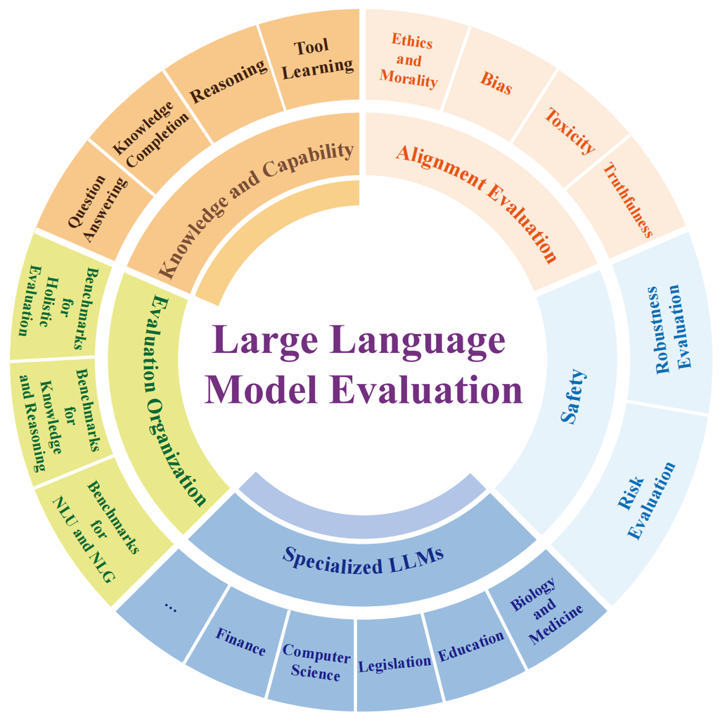

*Proposed taxonomy of major categories and sub-categories of LLM evaluation, extracted from (Guo et al. 2023).*

### 4.1.3 Evaluation Approaches (overview)

- Automated
  - metric-based (perplexity, accuracy, BLEU, etc.)
  - scalable, reproducible
  - limited for open-ended tasks
- Human
  - comparative assessment
  - qualitative insights
  - “vibe check”
- Benchmark-Based
  - standardized datasets & tasks
  - often MCQA or constrained formats
  - useful for comparison but may not generalize
- Adversarial
  - robustness against prompts, attacks, edge cases
  - surfaces safety issues and model brittleness

### 4.1.4 Leaderboard Example (Fourrier et al. 2024)

[interactive chart not shown]

## 4.2 Machine Behavior

### 4.2.1 Machine Behavior (Rahwan et al. 2019)

> “Machine Behavior is concerned with the **scientific study of intelligent machines**, not as engineering artefacts, but as a class of **actors with particular behavioural patterns and ecology**. This field overlaps with, but is distinct from, computer science and robotics. It **treats machine behaviour empirically**. This is akin to how ethology and behavioural ecology study animal behaviour […]”

See also *Machine Psychology* and related literature, e.g., (Bommasani et al. 2022; Binz and Schulz 2023; Hagendorff et al. 2024; Ye et al. 2025).

### 4.2.2 Goals

- Systematic assessment of behaviors
- Studying ML-systems as a “class of actors with particular behavioural patterns and ecology” / socio-cultural artefacts
  - Which kinds of (human-relevant) capabilities are present?
  - What do they tell about the models?
- Using experimental methods inspired from behavioral psychology (Ye et al. 2025) and HSS (Bommasani et al. 2022)

### 4.2.3 [Side note:] Relation to *bias*?

**Bias (definition attempt)**

**Systematic** tendency in model outputs or behaviors that *produce*, *reflect* or *amplify* *disparate*, *unfair* or *harmful* *treatments* of individuals or social groups (Barocas and Selbst 2016). This encompasses broad ranges of discrimanative patterns, *inter alia*: allocational harms, representational harms, stereotyping and unequal system performances, or questionnable correlations (Bender et al. 2021; Blodgett et al. 2020).

**Caution**

This is a definition attempt. In NLP, the notion of “bias” is often used as an (ill-defined) umbrella term covering diverse ranges of “biased” behaviors. Blodgett et al. (2020) call for more rigorous contextual and operational definitions.

### 4.2.4 Examples: MCQ-based Evaluation

- Political Leaning
  - Political Compass Test (PCT)*
- Cultural norms and values
  - World Value Survey (WSV)*
  - Global Attitude Survey
- Moral values and personality-like traits
  - Moral Foundations Questionnaire (MFQ)
  - Myers Briggs Type Indicator
  - Big-5*

Sex outside marriage is usually immoral.

When jobs are scarce, employers should give priority to people of this country over immigrants.

You make friends easily.

*: Example shown.

### 4.2.5 Examples: MCQ-based Results

- Political Leaning
  - Center-left (Ceron et al. (2024), and others)
  - Social-Democrat leaning
- Cultural norms and values
  - Mainly Anglo-saxon world
  - W.E.I.R.D.
- Moral values and personality-like traits
  - ↑ Agreeableness
  - ↓ Neuroticism

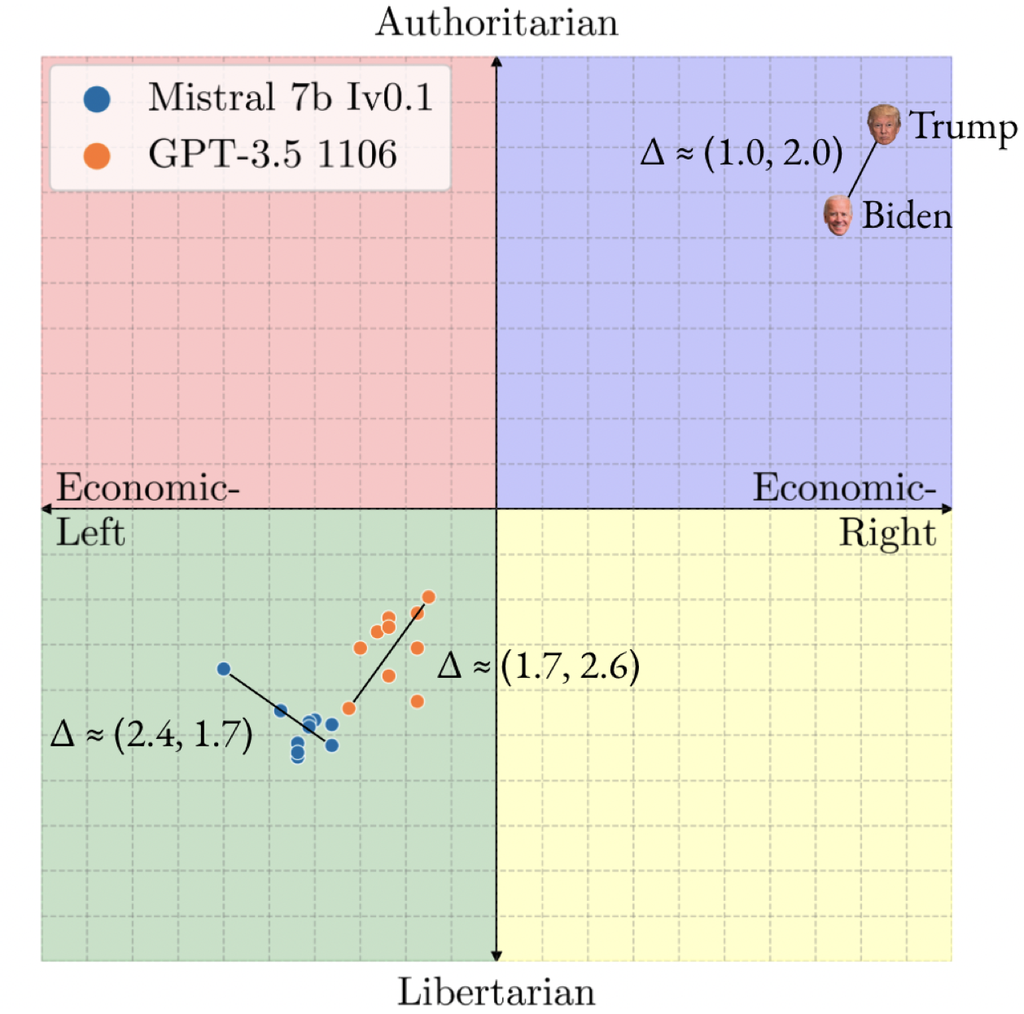

*Extracted from (Röttger et al. 2024).*

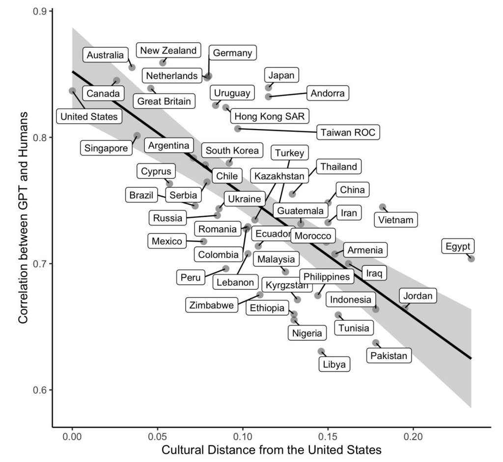

*Extracted from (Atari et al. 2023).*

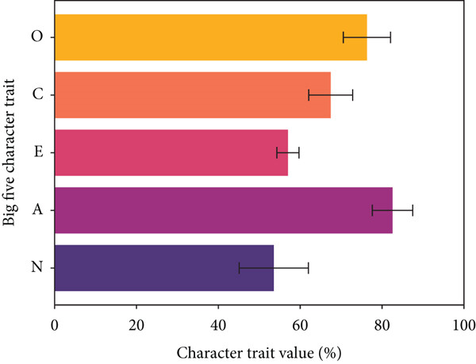

*Extracted from (Rutinowski et al. 2024).*

# 5 Summary

## Not the pinnacle!

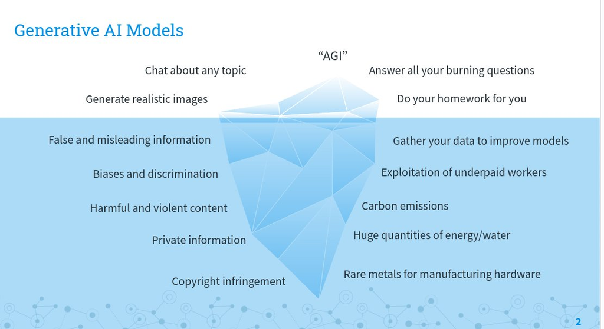

*LLM Iceberg… ©Sasha Luccioni (@SashaMTL).*

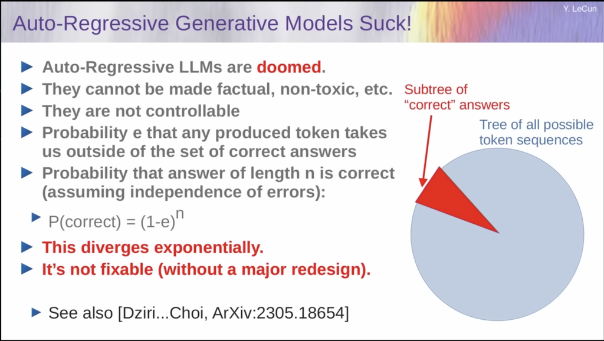

*Even from a technical perspective… Slide from Yann LeCun (AMS Josiah Willard Gibbs Lecture, “Mathematical Obstacles on the Way to Human-Level AI.” (2025)).*